# Part I - (Ford GoBike System Data)

## by (Ireyemi Stephen)

- Introduction
- Preliminary Wrangling
- Basic Cleaning and Investigation
- Univariate Exploration
- Bivariate Exploration
- Multivariate Exploration

## Introduction

> This data set includes information about individual rides made in a bike-sharing system covering the greater San Francisco Bay area. It contains 183412 observations with 16 associated variables.

## Preliminary Wrangling

```python
# import all packages and set plots to be embedded inline
import numpy as np
import pandas as pd
import matplotlib.pyplot as plt
import seaborn as sb
%matplotlib inline
```

```python
# load in the dataset into a pandas dataframe, print statistics

bikes = pd.read_csv('201902-fordgobike-tripdata.csv')
```

```python
# high-level overview of data shape and composition

print(bikes.shape)
print(bikes.dtypes)
```

```
(183412, 16)
duration_sec                 int64
start_time                  object
end_time                    object
start_station_id           float64
start_station_name          object
start_station_latitude     float64
start_station_longitude    float64
end_station_id             float64
end_station_name            object
end_station_latitude       float64
end_station_longitude      float64
bike_id                      int64
user_type                   object
member_birth_year          float64
member_gender               object
bike_share_for_all_trip     object
dtype: object
```

```python
bikes.head(10)
```

|  | duration_sec | start_time | end_time | start_station_id | start_station_name | start_station_latitude | start_station_longitude | end_station_id | end_station_name | end_station_latitude | end_station_longitude | bike_id | user_type | member_birth_year | member_gender | bike_share_for_all_trip |
| --- | --- | --- | --- | --- | --- | --- | --- | --- | --- | --- | --- | --- | --- | --- | --- | --- |
| 0 | 52185 | 2019-02-28 17:32:10.1450 | 2019-03-01 08:01:55.9750 | 21.0 | Montgomery St BART Station (Market St at 2nd St) | 37.789625 | -122.400811 | 13.0 | Commercial St at Montgomery St | 37.794231 | -122.402923 | 4902 | Customer | 1984.0 | Male | No |
| 1 | 42521 | 2019-02-28 18:53:21.7890 | 2019-03-01 06:42:03.0560 | 23.0 | The Embarcadero at Steuart St | 37.791464 | -122.391034 | 81.0 | Berry St at 4th St | 37.775880 | -122.393170 | 2535 | Customer | NaN | NaN | No |
| 2 | 61854 | 2019-02-28 12:13:13.2180 | 2019-03-01 05:24:08.1460 | 86.0 | Market St at Dolores St | 37.769305 | -122.426826 | 3.0 | Powell St BART Station (Market St at 4th St) | 37.786375 | -122.404904 | 5905 | Customer | 1972.0 | Male | No |
| 3 | 36490 | 2019-02-28 17:54:26.0100 | 2019-03-01 04:02:36.8420 | 375.0 | Grove St at Masonic Ave | 37.774836 | -122.446546 | 70.0 | Central Ave at Fell St | 37.773311 | -122.444293 | 6638 | Subscriber | 1989.0 | Other | No |
| 4 | 1585 | 2019-02-28 23:54:18.5490 | 2019-03-01 00:20:44.0740 | 7.0 | Frank H Ogawa Plaza | 37.804562 | -122.271738 | 222.0 | 10th Ave at E 15th St | 37.792714 | -122.248780 | 4898 | Subscriber | 1974.0 | Male | Yes |
| 5 | 1793 | 2019-02-28 23:49:58.6320 | 2019-03-01 00:19:51.7600 | 93.0 | 4th St at Mission Bay Blvd S | 37.770407 | -122.391198 | 323.0 | Broadway at Kearny | 37.798014 | -122.405950 | 5200 | Subscriber | 1959.0 | Male | No |
| 6 | 1147 | 2019-02-28 23:55:35.1040 | 2019-03-01 00:14:42.5880 | 300.0 | Palm St at Willow St | 37.317298 | -121.884995 | 312.0 | San Jose Diridon Station | 37.329732 | -121.901782 | 3803 | Subscriber | 1983.0 | Female | No |
| 7 | 1615 | 2019-02-28 23:41:06.7660 | 2019-03-01 00:08:02.7560 | 10.0 | Washington St at Kearny St | 37.795393 | -122.404770 | 127.0 | Valencia St at 21st St | 37.756708 | -122.421025 | 6329 | Subscriber | 1989.0 | Male | No |
| 8 | 1570 | 2019-02-28 23:41:48.7900 | 2019-03-01 00:07:59.7150 | 10.0 | Washington St at Kearny St | 37.795393 | -122.404770 | 127.0 | Valencia St at 21st St | 37.756708 | -122.421025 | 6548 | Subscriber | 1988.0 | Other | No |
| 9 | 1049 | 2019-02-28 23:49:47.6990 | 2019-03-01 00:07:17.0250 | 19.0 | Post St at Kearny St | 37.788975 | -122.403452 | 121.0 | Mission Playground | 37.759210 | -122.421339 | 6488 | Subscriber | 1992.0 | Male | No |

```python
# descriptive statistics for numeric variables
bikes.describe()
```

|  | duration_sec | start_station_id | start_station_latitude | start_station_longitude | end_station_id | end_station_latitude | end_station_longitude | bike_id | member_birth_year |
| --- | --- | --- | --- | --- | --- | --- | --- | --- | --- |
| count | 183412.000000 | 183215.000000 | 183412.000000 | 183412.000000 | 183215.000000 | 183412.000000 | 183412.000000 | 183412.000000 | 175147.000000 |
| mean | 726.078435 | 138.590427 | 37.771223 | -122.352664 | 136.249123 | 37.771427 | -122.352250 | 4472.906375 | 1984.806437 |
| std | 1794.389780 | 111.778864 | 0.099581 | 0.117097 | 111.515131 | 0.099490 | 0.116673 | 1664.383394 | 10.116689 |
| min | 61.000000 | 3.000000 | 37.317298 | -122.453704 | 3.000000 | 37.317298 | -122.453704 | 11.000000 | 1878.000000 |
| 25% | 325.000000 | 47.000000 | 37.770083 | -122.412408 | 44.000000 | 37.770407 | -122.411726 | 3777.000000 | 1980.000000 |
| 50% | 514.000000 | 104.000000 | 37.780760 | -122.398285 | 100.000000 | 37.781010 | -122.398279 | 4958.000000 | 1987.000000 |
| 75% | 796.000000 | 239.000000 | 37.797280 | -122.286533 | 235.000000 | 37.797320 | -122.288045 | 5502.000000 | 1992.000000 |
| max | 85444.000000 | 398.000000 | 37.880222 | -121.874119 | 398.000000 | 37.880222 | -121.874119 | 6645.000000 | 2001.000000 |

```python
# to find duplicates
bikes.duplicated().sum()
```

```
0
```

```python
# to find NaN values
bikes.isnull().sum()
```

```
duration_sec                  0
start_time                    0
end_time                      0
start_station_id            197
start_station_name          197
start_station_latitude        0
start_station_longitude       0
end_station_id              197
end_station_name            197
end_station_latitude          0
end_station_longitude         0
bike_id                       0
user_type                     0
member_birth_year          8265
member_gender              8265
bike_share_for_all_trip       0
dtype: int64
```

## Basic Cleaning and Investigation

### Quality Issues

1. Missing values in (`start_station_id, start_station_name, end_station_id, end_station_name, member_birth_year, member_gender`) columns
2. `start_time and end_times` should be in timestamp format
3. `start_station_id, end_station_id, bike_id` data types should be changed to string
4. `member_birth_year` should be converted to integer data type

```python
# to drop missing values
bikes.dropna(inplace=True)
```

```python
# to find NaN values
bikes.isnull().sum()
```

```
duration_sec               0
start_time                 0
end_time                   0
start_station_id           0
start_station_name         0
start_station_latitude     0
start_station_longitude    0
end_station_id             0
end_station_name           0
end_station_latitude       0
end_station_longitude      0
bike_id                    0
user_type                  0
member_birth_year          0
member_gender              0
bike_share_for_all_trip    0
dtype: int64
```

```python
# convert start_time and end_time to datetime datatype
bikes.start_time = pd.to_datetime(bikes.start_time)
bikes.end_time = pd.to_datetime(bikes.end_time)

# convert start_station_id, end_station_id, and bike_id to string datatype
bikes.start_station_id = bikes.start_station_id.astype('str')
bikes.end_station_id = bikes.end_station_id.astype('str')
bikes.bike_id = bikes.bike_id.astype('str')

# convert user_type and member_gender to category datatype
bikes.user_type = bikes.user_type.astype('category')
bikes.member_gender = bikes.member_gender.astype('category')
bikes.bike_share_for_all_trip = bikes.bike_share_for_all_trip.astype('category')
```

```python
# getting the age of the members from 'member_birth_year'  and convert it to integer

bikes['member_age'] = 2022 - bikes['member_birth_year']
bikes['member_age'] = bikes['member_age'].astype(int)
bikes.head()
```

|  | duration_sec | start_time | end_time | start_station_id | start_station_name | start_station_latitude | start_station_longitude | end_station_id | end_station_name | end_station_latitude | end_station_longitude | bike_id | user_type | member_birth_year | member_gender | bike_share_for_all_trip | member_age |
| --- | --- | --- | --- | --- | --- | --- | --- | --- | --- | --- | --- | --- | --- | --- | --- | --- | --- |
| 0 | 52185 | 2019-02-28 17:32:10.145 | 2019-03-01 08:01:55.975 | 21.0 | Montgomery St BART Station (Market St at 2nd St) | 37.789625 | -122.400811 | 13.0 | Commercial St at Montgomery St | 37.794231 | -122.402923 | 4902 | Customer | 1984.0 | Male | No | 38 |
| 2 | 61854 | 2019-02-28 12:13:13.218 | 2019-03-01 05:24:08.146 | 86.0 | Market St at Dolores St | 37.769305 | -122.426826 | 3.0 | Powell St BART Station (Market St at 4th St) | 37.786375 | -122.404904 | 5905 | Customer | 1972.0 | Male | No | 50 |
| 3 | 36490 | 2019-02-28 17:54:26.010 | 2019-03-01 04:02:36.842 | 375.0 | Grove St at Masonic Ave | 37.774836 | -122.446546 | 70.0 | Central Ave at Fell St | 37.773311 | -122.444293 | 6638 | Subscriber | 1989.0 | Other | No | 33 |
| 4 | 1585 | 2019-02-28 23:54:18.549 | 2019-03-01 00:20:44.074 | 7.0 | Frank H Ogawa Plaza | 37.804562 | -122.271738 | 222.0 | 10th Ave at E 15th St | 37.792714 | -122.248780 | 4898 | Subscriber | 1974.0 | Male | Yes | 48 |
| 5 | 1793 | 2019-02-28 23:49:58.632 | 2019-03-01 00:19:51.760 | 93.0 | 4th St at Mission Bay Blvd S | 37.770407 | -122.391198 | 323.0 | Broadway at Kearny | 37.798014 | -122.405950 | 5200 | Subscriber | 1959.0 | Male | No | 63 |

```python
# converting member_birth_year to integer datatype

bikes.member_birth_year = bikes.member_birth_year.astype(int)
```

```python
# to find the age average

bikes.member_age.mean()
```

```
37.196865425945404
```

```python
# to know the statistical description of member_age variables
bikes.member_age.describe()
```

```
count    174952.000000
mean         37.196865
std          10.118731
min          21.000000
25%          30.000000
50%          35.000000
75%          42.000000
max         144.000000
Name: member_age, dtype: float64
```

```python
bikes.member_age.describe(percentiles = [.99])
```

```
count    174952.000000
mean         37.196865
std          10.118731
min          21.000000
50%          35.000000
99%          67.000000
max         144.000000
Name: member_age, dtype: float64
```

- **From the age statistical description, it can be concluded that 99% of users are under the age 67**

```python
# to keep only events where riders are under 67 years of age
bikes = bikes.query('member_age <= 67')
```

```python
# to drop unnecessary columns
bikes.drop(['start_station_latitude', 'start_station_longitude','end_station_latitude','end_station_longitude', 'member_birth_year'], axis=1, inplace=True)
```

```python
bikes.describe()
```

|  | duration_sec | member_age |
| --- | --- | --- |
| count | 173272.000000 | 173272.000000 |
| mean | 703.878549 | 36.828253 |
| std | 1647.305625 | 9.378430 |
| min | 61.000000 | 21.000000 |
| 25% | 323.000000 | 30.000000 |
| 50% | 510.000000 | 35.000000 |
| 75% | 788.000000 | 42.000000 |
| max | 84548.000000 | 67.000000 |

```python
# to add new columns for trip duration in minute, hour of the day, day of week and month

bikes['duration_minute'] = bikes['duration_sec']/60
bikes['start_date'] = bikes.start_time.dt.strftime('%d-%m-%Y')
bikes['start_hourofday'] = bikes.start_time.dt.strftime('%H')
bikes['start_dayofweek'] = bikes.start_time.dt.strftime('%A')
bikes['start_month'] = bikes.start_time.dt.strftime('%B')

bikes.head()
```

|  | duration_sec | start_time | end_time | start_station_id | start_station_name | end_station_id | end_station_name | bike_id | user_type | member_gender | bike_share_for_all_trip | member_age | duration_minute | start_date | start_hourofday | start_dayofweek | start_month |
| --- | --- | --- | --- | --- | --- | --- | --- | --- | --- | --- | --- | --- | --- | --- | --- | --- | --- |
| 0 | 52185 | 2019-02-28 17:32:10.145 | 2019-03-01 08:01:55.975 | 21.0 | Montgomery St BART Station (Market St at 2nd St) | 13.0 | Commercial St at Montgomery St | 4902 | Customer | Male | No | 38 | 869.750000 | 28-02-2019 | 17 | Thursday | February |
| 2 | 61854 | 2019-02-28 12:13:13.218 | 2019-03-01 05:24:08.146 | 86.0 | Market St at Dolores St | 3.0 | Powell St BART Station (Market St at 4th St) | 5905 | Customer | Male | No | 50 | 1030.900000 | 28-02-2019 | 12 | Thursday | February |
| 3 | 36490 | 2019-02-28 17:54:26.010 | 2019-03-01 04:02:36.842 | 375.0 | Grove St at Masonic Ave | 70.0 | Central Ave at Fell St | 6638 | Subscriber | Other | No | 33 | 608.166667 | 28-02-2019 | 17 | Thursday | February |
| 4 | 1585 | 2019-02-28 23:54:18.549 | 2019-03-01 00:20:44.074 | 7.0 | Frank H Ogawa Plaza | 222.0 | 10th Ave at E 15th St | 4898 | Subscriber | Male | Yes | 48 | 26.416667 | 28-02-2019 | 23 | Thursday | February |
| 5 | 1793 | 2019-02-28 23:49:58.632 | 2019-03-01 00:19:51.760 | 93.0 | 4th St at Mission Bay Blvd S | 323.0 | Broadway at Kearny | 5200 | Subscriber | Male | No | 63 | 29.883333 | 28-02-2019 | 23 | Thursday | February |

```python
print(bikes.shape)
print(bikes.dtypes)
```

```
(173272, 17)
duration_sec                        int64
start_time                 datetime64[ns]
end_time                   datetime64[ns]
start_station_id                   object
start_station_name                 object
end_station_id                     object
end_station_name                   object
bike_id                            object
user_type                        category
member_gender                    category
bike_share_for_all_trip          category
member_age                          int64
duration_minute                   float64
start_date                         object
start_hourofday                    object
start_dayofweek                    object
start_month                        object
dtype: object
```

```python
bikes.describe()
```

|  | duration_sec | member_age | duration_minute |
| --- | --- | --- | --- |
| count | 173272.000000 | 173272.000000 | 173272.000000 |
| mean | 703.878549 | 36.828253 | 11.731309 |
| std | 1647.305625 | 9.378430 | 27.455094 |
| min | 61.000000 | 21.000000 | 1.016667 |
| 25% | 323.000000 | 30.000000 | 5.383333 |
| 50% | 510.000000 | 35.000000 | 8.500000 |
| 75% | 788.000000 | 42.000000 | 13.133333 |
| max | 84548.000000 | 67.000000 | 1409.133333 |

### What is the structure of your dataset?

> My dataset structure for Ford GoBike's bike-sharing system covering the greater San Francisco Bay area, contains 173272 observations(rows/samples) with 17 features(columns).

### What is/are the main feature(s) of interest in your dataset?

> My main features of interest includes: `start_hourofday`, `start_dayofweek` and `duration_minutes`.

### What features in the dataset do you think will help support your investigation into your feature(s) of interest?

> These includes: `user_type`, `member_gender`, `member_age`, `start_time`, `end_time`.

## Univariate Exploration

### What is the distribution of `user_type` ?

```
Subscriber    90.487788
Customer       9.512212
Name: user_type, dtype: float64
```

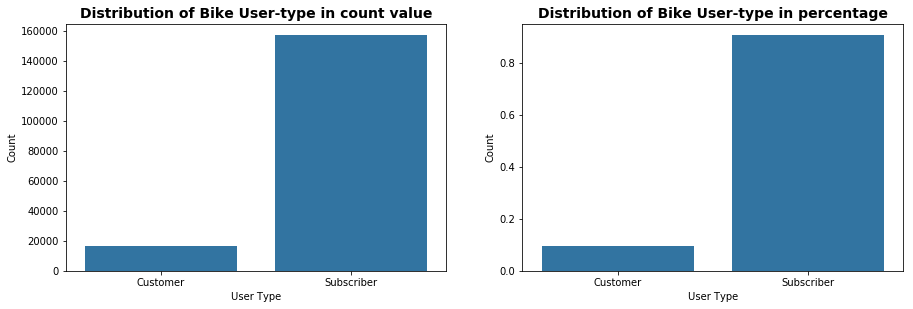

```python
plt.figure(figsize = [15, 10])
color = sb.color_palette()[0]

plt.subplot(2, 2, 1)
plot = sb.countplot(data=bikes, x='user_type', color= color)
plt.xlabel('User Type')
plt.ylabel('Count')
plt.title("Distribution of Bike User-type in count value" , fontsize=14, fontweight='bold')



plt.subplot(2, 2, 2)
counts = bikes['user_type'].value_counts(normalize = True)
sb.barplot(x = counts.index, y = counts.values, color=color)
plt.xlabel('User Type')
plt.ylabel('Count')
print(counts * 100)
plt.title("Distribution of Bike User-type in percentage" , fontsize=14, fontweight='bold');
```

#### Observation :

From subplot (2, 2, 2); approximately 90.5% of bike users are Subscribers while 9.5% are Customers.

### What is distribution of `memeber_gender` that use the bike system?

```
Male      129101
Female     40574
Other       3597
Name: member_gender, dtype: int64
```

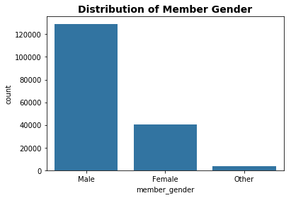

```python
# to get distribution of member gender using count plot

print(bikes.member_gender.value_counts())
gender= bikes.member_gender.value_counts().index
color = sb.color_palette()[0]
sb.countplot(data=bikes , x='member_gender' , color=color , order=gender)
plt.title("Distribution of Member Gender" , fontsize=14, fontweight='bold');
```

#### Observation:

Most users of the bike system are the male gender.

### What is distribution of `member_age` that use the bike system?

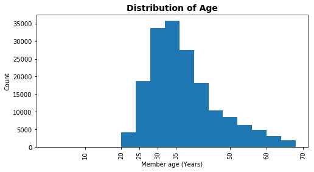

```python
# to get distributin of age group data
plt.figure(figsize = (8,4))
bins = np.arange(0, bikes['member_age'].max()+4, 4)
ticks = [ 10, 20, 25, 30, 35, 50, 60, 70]
labels = ['{}'.format(v) for v in ticks]
color = sb.color_palette()[0]
plt.hist(data=bikes, x='member_age', color= color, bins = bins)
plt.xticks(rotation=90)
plt.xlabel('Member age (Years)')
plt.ylabel('Count')
plt.title('Distribution of Age' , fontsize=14, fontweight='bold')
plt.xticks(ticks, labels);
```

### Observations:

1. The age distribution is right-skewed.
2. The mean age of the distribution is between age 36 and age 37.
3. The mode of the distribution is age 34, that means most users of the bike system are 34years of age.

### What is the bike-trip distribution by `duration_minutes`?

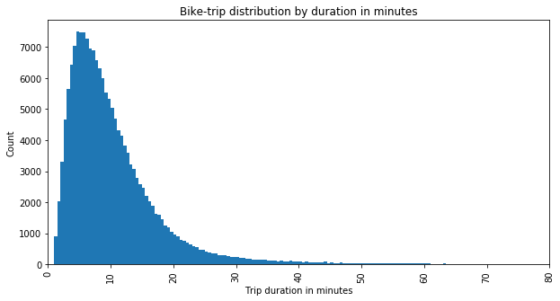

```python
# trip distribution by duration
plt.figure(figsize = (10, 5))
bins = np.arange(0, bikes['member_age'].max()+0.5, 0.5)


color = sb.color_palette()[0]
plt.hist(data=bikes, x='duration_minute', color= color, bins = bins)
plt.xticks(rotation=90)
plt.xlim(0, 80)
plt.xlabel('Trip duration in minutes')
plt.ylabel('Count')
plt.title("Bike-trip distribution by duration in minutes")
plt.show()
```

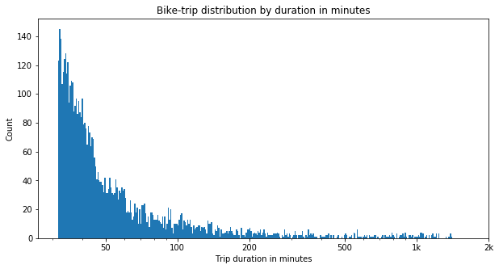

```python
# there's a long tail in the distribution, so let's put it on a log scale instead

log_binsize = 0.005
bins = 10 ** np.arange(1.5, np.log10(bikes['duration_minute'].max())+log_binsize, log_binsize)

plt.figure(figsize=(10, 5))
plt.hist(data = bikes, x = 'duration_minute', bins = bins)
plt.xscale('log')
plt.xticks ([50, 100, 200, 500, 1e3, 2e3], [50, 100, 200, 500, '1k', '2k'])
plt.xlabel('Trip duration in minutes')
plt.ylabel('Count')
plt.title("Bike-trip distribution by duration in minutes")
plt.show()
```

#### Observation A:

1. The distribution of duration(minutes) is right-skewed.
2. It seems that most bike-trips were less than 30 minutes.

```python
# To find the percentage of trips that were less than 30 minutes

len(bikes[bikes["duration_minute"] <= 30]) / len(bikes["duration_minute"]) * 100
```

```
96.56609261738768
```

```python
len(bikes[bikes["duration_minute"] > 60]) / len(bikes["duration_minute"]) * 100
```

```
0.79239577081121
```

#### Observation B:

From the distribution of trip duration(minutes), it is observed that more than 96% of trips took less than 30 minutes and only 0.79% of trips are of duration more than 1 hour. The trips greater than 60 minutes might be considered as outliers that needs to be removed when carrying out the bivariate analysis.

### What is the bike-trip distribution by `start_hourofday`?

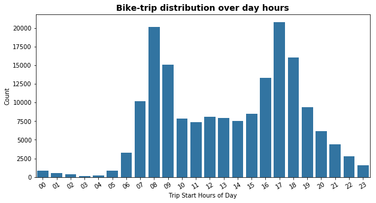

```python
# bike-trip distribution over day hours
plt.figure(figsize = (10,5))

hour = ['00', '01', '02', '03', '04', '05', '06', '07', '08', '09', '10', '11', '12', '13', '14', '15', '16', '17', '18', '19', '20', '21', '22', '23']
hour_category = pd.api.types.CategoricalDtype(ordered=True, categories=hour)
bikes['start_hourofday'] = bikes['start_hourofday'].astype(hour_category)
color = sb.color_palette()[0]

sb.countplot(data = bikes, x = "start_hourofday", color = color)
plt.title('Bike-trip distribution over day hours' , fontsize=14, fontweight='bold')
plt.xlabel('Trip Start Hours of Day')
plt.ylabel('Count')
plt.xticks(rotation = 30)
plt.show()
```

#### Observation:

From the countplot above we can notice that peak hours are from 7 - 9 am and from 4 - 6 pm. This might be due to the fact that people leave their homes and head back home at those peak hours.

### What is the bike-trip distribution by `start week_day`?

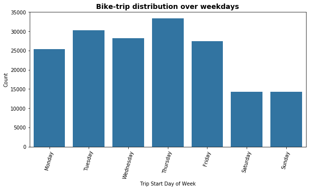

```python
# bike-trip distribution over weekday
plt.figure(figsize = (10,5))

weekday = ['Monday', 'Tuesday', 'Wednesday', 'Thursday', 'Friday', 'Saturday', 'Sunday']
weekday_category = pd.api.types.CategoricalDtype(ordered=True, categories=weekday)
bikes['start_dayofweek'] = bikes['start_dayofweek'].astype(weekday_category)
color = sb.color_palette()[0]

sb.countplot(data=bikes, x='start_dayofweek', color= color)
plt.xlabel('Trip Start Day of Week')
plt.xticks(rotation=75)
plt.ylabel('Count')
plt.title("Bike-trip distribution over weekdays", fontsize=14, fontweight='bold')

plt.show()
```

#### Observation:

1. Tuesday and Thursday are the most popular days for using the bike-sharing system
2. Saturday and Sunday have the least count of bike-users as they are regarded as resting days.

> **Rubric Tip**: Visualizations should depict the data appropriately so that the plots are easily interpretable. You should choose an appropriate plot type, data encodings, and formatting as needed. The formatting may include setting/adding the title, labels, legend, and comments. Also, do not overplot or incorrectly plot ordinal data.

### Discuss the distribution(s) of your variable(s) of interest. Were there any unusual points? Did you need to perform any transformations?

For now, there was not any usual point, except that I had to add x_tick values to get the mode in the age distribution plot.

### Of the features you investigated, were there any unusual distributions? Did you perform any operations on the data to tidy, adjust, or change the form of the data? If so, why did you do this?

The distribution of the trip duration(in minutes) was a little surprising at first plotting out the original data, then i transformed the x-axis to log scale but it brought the same result(a unimodal distribution)

## Bivariate Exploration

### Does user type affect bike trip-time ?

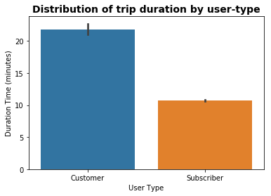

```python
# plotting relation between user type and trip time
user_count = bikes.user_type.value_counts().index

sb.barplot(y='duration_minute' , x='user_type' ,data=bikes );
plt.xlabel('User Type')
plt.ylabel('Duration Time (minutes)');
plt.title("Distribution of trip duration by user-type", fontsize=14, fontweight='bold' );
```

#### Observation:

Customer users spend more time using the Ford bikes than subscriber users even though from our univariate analysis, most users of the bike-sharing are the subscribers.

### How does member age affect bike trip-time ?

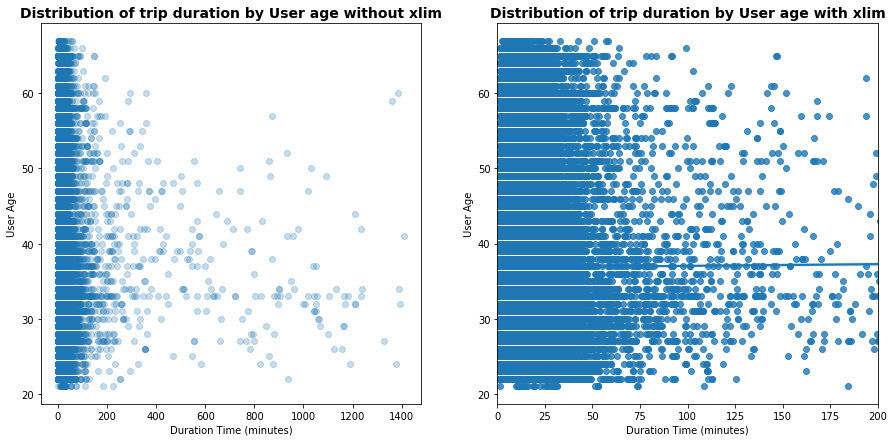

```python
# plotting relation between ages and trip time

plt.figure(figsize=(15, 7))


plt.subplot(1, 2, 1)
plt.scatter(data=bikes,  x = 'duration_minute', y = 'member_age', alpha=5/20);
plt.xlabel('Duration Time (minutes)')
plt.ylabel('User Age')
plt.title("Distribution of trip duration by User age without xlim", y = 1, fontsize=14, fontweight='bold')

plt.subplot(1, 2, 2)
sb.regplot(data = bikes, x = 'duration_minute', y = 'member_age');
plt.xlim([0,200])
plt.xlabel('Duration Time (minutes)')
plt.ylabel('User Age');
plt.title("Distribution of trip duration by User age with xlim", y = 1, fontsize=14, fontweight='bold');
```

### What is the relationship between member gender and bike trip-time ?

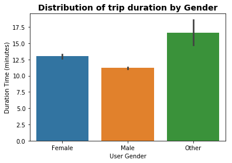

```python
#plotting relation between gender and trip time
sb.barplot(data = bikes, x = 'member_gender', y = 'duration_minute')
plt.xlabel('User Gender')
plt.ylabel('Duration Time (minutes)')
plt.title("Distribution of trip duration by Gender", fontsize=14, fontweight='bold' );
```

#### Observation :

The Other gender have the highest bike trip time compared to the Female and Male gender. The male gender however spends the least time biking from the barplot above.

### What is the relationship between Start_dayofweek and user_type?

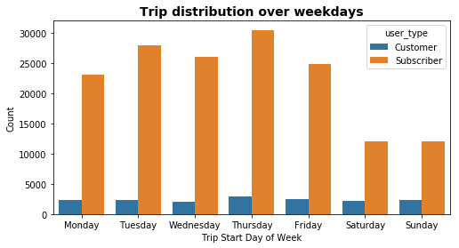

```python
#plotting relation between Trip Start Day of Week and user type

plt.figure(figsize = (8,4))

sb.countplot(data=bikes, x='start_dayofweek', hue='user_type')
plt.xlabel('Trip Start Day of Week')
plt.ylabel('Count')
plt.title("Trip distribution over weekdays",fontsize=14, fontweight='bold' )

plt.show()
```

#### Observations:

1. The number of subscribers that use the biking system each day of the week is more than that of the customers.
1. Thursday has the highest count of days for both subcribers and customers.
1. Users generally rest Saturdays and Sundays thats why user count is the lowest on those days.

### What is the relationship between Start_hourofday and user_type?

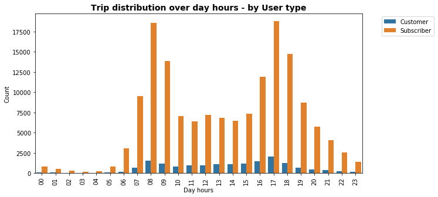

```python
#plotting relation between Trip Start hour of the day and user type

plt.figure(figsize = (10,5))
sb.countplot(data = bikes, x = "start_hourofday", hue='user_type')

plt.xlabel('Day hours')
plt.xticks(rotation = 90)
plt.ylabel('Count')
plt.title("Trip distribution over day hours - by User type", fontsize=14, fontweight='bold')
plt.legend(bbox_to_anchor=(1.05, 1), loc='upper left');
```

#### Observations :

1. Both user-types have the same peak hours which are from 7 - 9 am and from 4 - 6 pm. This might be due to the fact that people leave their homes and head back home at those peak hours.
1. Subscribers must really be risk takers as they ride bikes at midnight hours.

### What the number of trips by week-day and user type?

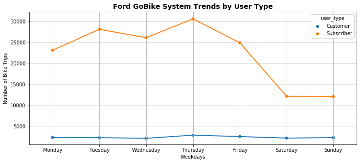

```python
# plotting relation of number of bike-trips to weekdays by user-type
plt.figure(figsize=(12, 5))

bikes_user_week = bikes.groupby(['start_dayofweek', 'user_type']).size().reset_index()
weekday = ['Monday', 'Tuesday', 'Wednesday', 'Thursday', 'Friday', 'Saturday', 'Sunday']

ax = sb.pointplot(data=bikes_user_week, x='start_dayofweek', y=0, hue = 'user_type', scale=.7, order = weekday);

plt.xlabel('Weekdays')
plt.ylabel('Number of Bike Trips')
plt.title('Ford GoBike System Trends by User Type', fontsize=14, fontweight='bold')
plt.grid()
```

#### Observations:

1. Customers have a generally low number of bike trips, there is relatively small change it its trend on the pointplot above while Subscribers are the opposite.
1. After thursday the general use of the Ford Bike system reduces because weekend is approaching.

### How is member gender and member age related?

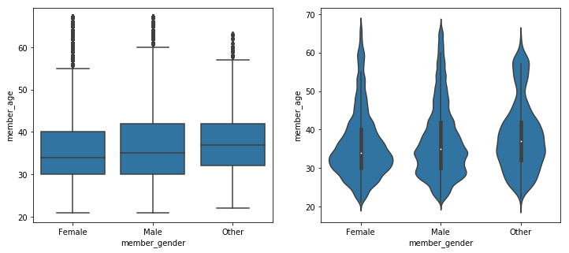

```python
# plotting relation between member age and member gender

plt.figure(figsize=(12, 5))
color = sb.color_palette()[0]

plt.subplot(1, 2, 1)
# plotting box plot
sb.boxplot(data=bikes, x='member_gender', y='member_age', color =color)

plt.subplot(1, 2, 2)
# plotting violin
sb.violinplot(data=bikes, x='member_gender', y='member_age', innner=None, color=color);
```

### How is user type and member age related?

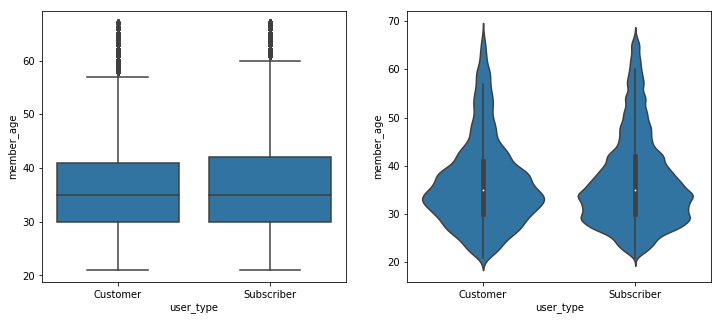

```python
# plotting relation between Trip member age and user type

plt.figure(figsize=(12, 5))
color = sb.color_palette()[0]

plt.subplot(1, 2, 1)
# plotting box plot
sb.boxplot(data=bikes, x='user_type', y='member_age', color = color)

plt.subplot(1, 2, 2)
# plotting violin
sb.violinplot(data=bikes, x='user_type', y='member_age', innner=None , color = color);
```

#### Observations:

1. Customers and Subscribers have very close middle quartile range, that means they have very close average.
1. From the boxplot above subsribers have older bikers to customers.

### Talk about some of the relationships you observed in this part of the investigation. How did the feature(s) of interest vary with other features in the dataset?

1. Customer users spend more time using the Ford bikes than subscriber users even though from our univariate analysis, most users of the bike-sharing system are the subscribers.
1. Most trips did not take 1hr,the age with highest trip duration seems to be users around age 34.
1. The number of subscribers everyday of the week is higher than that of customers.Thursday has the highest count of days for both subcribers and customers. Weekends have the lowest bike usage days because its regarded as time of rest.
1. Both user-types have the same peak hours which are from 7 - 9 am and from 4 - 6 pm. This might be due to the fact that people leave their homes and head back home at those peak hours.

### Did you observe any interesting relationships between the other features (not the main feature(s) of interest)?

1. Subsribers have older bikers to customers.
1. Male and Other gender have very close maximum age in the distrubution.

## Multivariate Exploration

### Correlation matrix of numerical variables

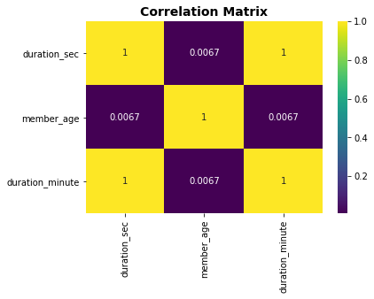

```python
sb.heatmap(bikes.corr(), cmap = "viridis", annot = True)
plt.title("Correlation Matrix", fontsize=14, fontweight='bold' )
plt.xticks(rotation = 90)
plt.legend(bbox_to_anchor=(1.05, 1), loc='upper left')

plt.show()
```

#### Observation:

There is no correlation between duration and member age.

### What is the trip duration over weekdays by user type?

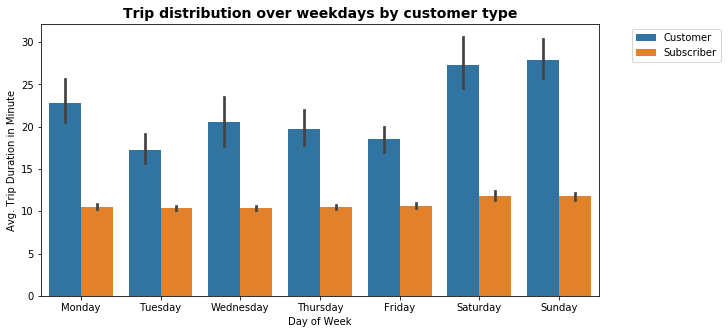

```python
plt.figure(figsize = (10,5))

sb.barplot(data = bikes, x = "start_dayofweek", y = "duration_minute", hue='user_type')
plt.xlabel('Day of Week');
plt.ylabel('Avg. Trip Duration in Minute')
plt.legend(bbox_to_anchor=(1.05, 1), loc='upper left')
plt.title("Trip distribution over weekdays by customer type", fontsize=14, fontweight='bold')

plt.show()
```

#### Observation:

1. Customers spend more time riding bikes everyday of the week that subscribers.
1. It seems that most subscribers spend an average of 10 minutes to ride bikes during the week.
1. Both users have longer trip-time during the weekend than other days of the week.

### What is the trip duration over hour of d by user type?

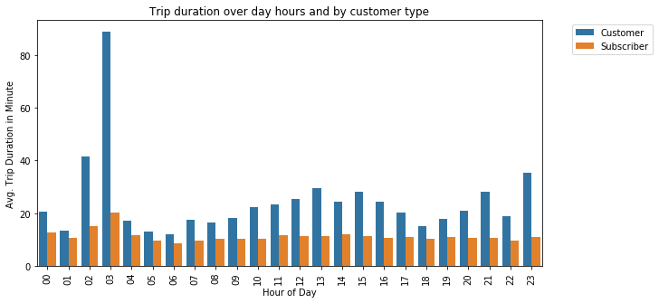

```python
plt.figure(figsize = (10,5))

sb.barplot(data = bikes, x = "start_hourofday", y = "duration_minute",   hue='user_type', ci = None)
plt.title("Trip duration over day hours and by customer type")
plt.xlabel('Hour of Day')
plt.ylabel('Avg. Trip Duration in Minute')
plt.xticks(rotation = 90)
plt.legend(bbox_to_anchor=(1.05, 1), loc='upper left')

plt.show()
```

### Trip duration over member age by customer type?

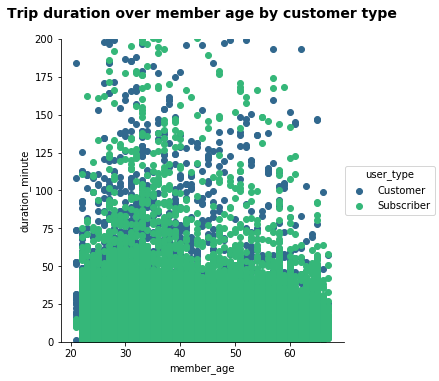

```python
plt.figure(figsize = (15,5))
g = sb.FacetGrid(data = bikes, hue = 'user_type', size = 5, palette = 'viridis')
g.map(plt.scatter, 'member_age', 'duration_minute')
g.add_legend()

plt.ylim([0,200])
plt.title("Trip duration over member age by customer type" ,  y= 1.05 , fontsize=14, fontweight='bold');
```

### What is the relationship between trip week day and hour of day by user type?

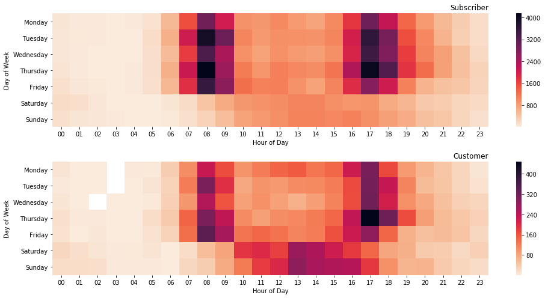

```python
plt.figure(figsize = (14,7))

plt.subplot(2, 1, 1)
customers = bikes[bikes['user_type'] == "Subscriber"]
ct_counts = customers.groupby(['start_dayofweek', 'start_hourofday']).size()
ct_counts = ct_counts.reset_index(name='count')
ct_counts = ct_counts.pivot(index='start_dayofweek', columns='start_hourofday', values='count')
sb.heatmap(ct_counts, cmap='rocket_r');
plt.title('Subscriber', loc='right');
plt.xlabel('Hour of Day');
plt.ylabel('Day of Week');

plt.subplot(2, 1, 2)
customers = bikes[bikes['user_type'] == "Customer"]
ct_counts = customers.groupby(['start_dayofweek', 'start_hourofday']).size()
ct_counts = ct_counts.reset_index(name='count')
ct_counts = ct_counts.pivot(index='start_dayofweek', columns='start_hourofday', values='count')
sb.heatmap(ct_counts, cmap='rocket_r');
plt.title('Customer', loc='right');
plt.xlabel('Hour of Day');
plt.ylabel('Day of Week');

plt.tight_layout()
```

#### Observations:

From the subscribers heatplot:

1. Highest number of subscribers are on Tuesday 8am and Thursday 8am & 5pm having an average of 4000 subscribers.
1. From the plot it is obvious that subscribers use bikes everyday of the week at every hour of the day.

From the customers heatplot:

1. Thursday 5pm has the highest bike usage.
1. There are days when customers did not use bikes at some givens hours. This is obvious on Monday and Tuesday 3am and Wednesday 2am.

Comparing both heatplots; it is seen that at mid-hours of the day subscribers did not use bikes as the customers compared to their distribution respectively.

### Were there any interesting or surprising interactions between features?

Yes! It was really surprising to see customers biking at midnight hours

## Conclusions

This dataset was analysed using the following steps; introduction, premliminary wrangling, Univariate exploration, Bivariate exploration and Multivariate exploration.

### References

1. https://classroom.udacity.com/nanodegrees/nd002-alg-t2/parts/cd0016
2. https://www.kaggle.com/code/ahmedmohameddawoud/ford-go-bike-detailed-visual-exploration